# W3cubDocs

## Examples using `matplotlib.patches.Circle`

[figure not shown]

[Clipping images with patches](https://matplotlib.org/3.5.1/gallery/images_contours_and_fields/image_clip_path.html#sphx-glr-gallery-images-contours-and-fields-image-clip-path-py)

[figure not shown]

[Axes box aspect](https://matplotlib.org/3.5.1/gallery/subplots_axes_and_figures/axes_box_aspect.html#sphx-glr-gallery-subplots-axes-and-figures-axes-box-aspect-py)

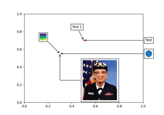

[AnnotationBbox demo](https://matplotlib.org/3.5.1/gallery/text_labels_and_annotations/demo_annotation_box.html#sphx-glr-gallery-text-labels-and-annotations-demo-annotation-box-py)

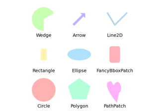

[Reference for Matplotlib artists](https://matplotlib.org/3.5.1/gallery/shapes_and_collections/artist_reference.html#sphx-glr-gallery-shapes-and-collections-artist-reference-py)

[figure not shown]

[Dolphins](https://matplotlib.org/3.5.1/gallery/shapes_and_collections/dolphin.html#sphx-glr-gallery-shapes-and-collections-dolphin-py)

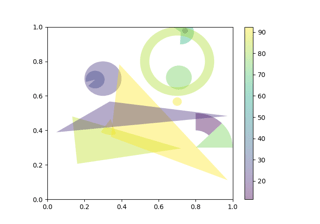

[Circles, Wedges and Polygons](https://matplotlib.org/3.5.1/gallery/shapes_and_collections/patch_collection.html#sphx-glr-gallery-shapes-and-collections-patch-collection-py)

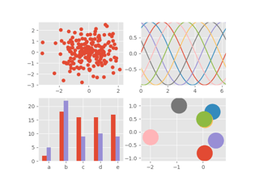

[ggplot style sheet](https://matplotlib.org/3.5.1/gallery/style_sheets/ggplot.html#sphx-glr-gallery-style-sheets-ggplot-py)

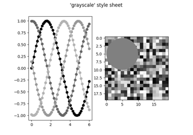

[Grayscale style sheet](https://matplotlib.org/3.5.1/gallery/style_sheets/grayscale.html#sphx-glr-gallery-style-sheets-grayscale-py)

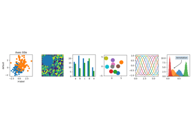

[Style sheets reference](https://matplotlib.org/3.5.1/gallery/style_sheets/style_sheets_reference.html#sphx-glr-gallery-style-sheets-style-sheets-reference-py)

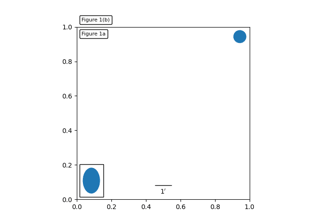

[Simple Anchored Artists](https://matplotlib.org/3.5.1/gallery/axes_grid1/simple_anchored_artists.html#sphx-glr-gallery-axes-grid1-simple-anchored-artists-py)